# BCOR 102 Lecture Notes

Nicholas J. Gotelli

Department of Biology, University of Vermont

**Latest Update: 28 October 2017**

These lecture notes provide you with a study guide for the Population Genetics and Evolution material from the second half of the class. This set of notes was originally written from the Fall 2015 lectures. I have left the lecture headings in place, but not with the original dates. Each year, the precise order and timing of the lectures may not match this sequence, but these notes should work well with the material from class.

# Lecture #1

## Definitions

`evolution (general definition)` Sustained change in the phenotype (= appearance) of a system through time; includes non-biological phenomena such as the universe, culture, music

`evolution (biological)` Change in the allele frequencies of a population through time

`genotype` Underlying genetic constitution of an organism

`phenotype` Physical appearance of an organism; its observed traits

$$genotype
\stackrel{\mbox{environment,development}}{\longrightarrow}
phenotype$$

$$phenotype = genotype +
environment$$

`gene` A section of DNA on a chromosome that codes for a specific trait (*e.g.*, flower color);

`locus` location on a chromosome where a gene occurs

`allele` One of two or more alternative states that exist for a gene (*e.g.*, red, white, purple)

`homozygote` Individual that has 2 identical alleles at a locus (*rr* or *RR*)

`heterozygote` Individual that has 2 different alleles at a locus (*Rr*)

`dominant allele` One whose phenotype is expressed in either homozygous or heterozygous individuals

`recessive allele` One whose phenotype is expressed only in homozygous individuals

## Complications of Mendelian Inheritance

`pleiotropy` A single gene affects more than one trait

`epistasis` Gene-gene interactions; the expression of one gene affects another

`polygenic trait` Small additive effects of many genes on a single trait, such as body mass

`environmental effects` The same genotype can have a different phenotype depending on the environment in which it is raised (*e.g.* appearance of same plant clone raised in sun versus shade)

The combination of environmental effects and a polygenic trait leads to a trait that is measured on a continuous scale, and often has a normal or bell-shaped distribution. For example, body mass or height is a continuous trait. But if it were inherited as a single Mendelian gene with only 2 alleles and no environmental effects, individuals would be of only two sizes: “tall” or “short”.

## Analysis of a Punnet Square

A Punnet square is a simple table to determine the genotypes and phenotypes produced from a parental cross. You need to know the genotypes of both parents to draw the square.

1. Along the top of the square, list the gamete types that could be produced by one of the parents.
2. Along the side of the square, list the gamete types that could be produced by the other parent.

Remember that each gamete type is equally likely, so divide the rows and columns of the square evenly.

3. Inside each cell of the table, write the resulting genotype and phenotype of the offspring. Each of these cells is equally probable.
4. Tabulate the relative frequencies of the different genotypes and the different phenotypes in the offspring.

## Example Punnet Square for a Single Gene with Two Alleles

### Alleles

*R* = red flower color  
*r* = white flower color

### Parental Genotypes and Phenotypes

Father’s genotype: *rr*  
Father’s phenotype: white flower

Mother’s genotype: *Rr*  
Mother’s phenotype: red flower

| Gametes | *r* | *r* |
| --- | --- | --- |
| *R* | *rR* | *rR* |
| *r* | *rr* | *rr* |

Offspring genotypic frequencies: Rr:rr 0.5:0.5  
Offspring phenotypic frequencies: red:white 0.5:0.5

## Example Punnet Square for Two Genes with Two Alleles Each

### Alleles

*R* = red flower color  
*r* = white flower color  
*Y* = smooth seed coat  
*y* = wrinkled seed coat

### Parental Genotypes and Phenotypes

Father’s genotype: *RrYy*  
Father’s phenotype: red flower, smooth seed coat

Mother’s genotype: *RrYy*  
Mother’s phenotype: red flower, smooth seed coat

| Gametes | *RY* | *rY* | *Ry* | *ry* |
| --- | --- | --- | --- | --- |
| *RY* | *RRYY* | *RrYY* | *RRYy* | *RrYy* |
| *rY* | *RrYY* | *rrYY* | *RrYy* | *rrYy* |
| *Ry* | *RRYy* | *RrYy* | *RRyy* | *Rryy* |
| *ry* | *RrYy* | *rrYy* | *Rryy* | *rryy* |

Offspring genotypes: RRYY: RRYy: RRyy: RrYY: RrYy: Rryy: rrYY: rrYy: rryy  
Offspring genotype counts: 1: 2: 1: 2: 4: 2: 1: 2: 1  
Offspring genotypic frequencies: $\frac{1}{16},\frac{2}{16},\frac{1}{16},\frac{2}{16},\frac{4}{16},\frac{2}{16},\frac{1}{16},\frac{2}{16},\frac{1}{16}$

Offspring phenotypes: RedSmooth: Redwrinkled: whiteSmooth: whitewrinkled  
Offspring phenotype counts: 9: 3: 3: 1  
Offspring phenotypic frequencies: $\frac{9}{16},\frac{3}{16},\frac{3}{16},\frac{1}{16}$

# Lecture #2

## Definitions

`gene pool` The set of all alleles in an interbreeding population

`genotypic frequencies` The proportion of different genotypes in the population

`allelic frequencies` The proportion of different alleles in the population (regardless of genotype)

## Calculating Genotypic and Allelic Frequencies

The genotypic and allelic frequencies can always be calculated directly from data in which a sample of individuals from a population is genotyped (from direct sequencing, SNP analysis, or measures of protein diversity). This calculation of observed genotypic and allelic frequencies does not make any assumptions about evolution or genetic change; it is just a snapshot of genetic diversity that has been measured.

Here are some sample data in the form of counts of different genotypes for a single gene locus:

| Genotype | AA | AB | BB | Sum |
| --- | --- | --- | --- | --- |
| Number of individuals | 75 | 20 | 100 | 195 |

### Calculating Genotypic Frequencies

```
f(AA) = 75/195 = 0.385
f(AB) = 20/195 = 0.103
f(BB) = 100/195 = 0.512
```

### Calcuating Allelic Frequencies

The allelic frequency calculation is slightly more calculated. Remember that each homozygote carries two copies of a particular allele, but a heterozygote carries only a single copy. So, we use `0.5 x f(AB)` to get the contribution of the heterozygote to the allelic frequency:

```
f(A) = f(AA) + 0.5*f(AB)
f(A) = 0.385 + 0.5*0.103 = 0.436

f(B) = F(BB) + 0.5*f(AB)
f(B) = 0.512 + 0.5*0.103 = 0.564
```

As a check on your work, make sure that the genotypic frequencies sum to 1.0 and the phenotypic frequencies sum to 1.0.

### Calculating Genotypic and Allelic Frequencies When There Are More Than Two Alleles

This is slightly more complex, because you have to list out all of the possible genotypes, but the formulas are essentially the same. Here is an example of a single gene with 3 alleles J, K, and L

| Genotype | JJ | JK | JL | KL | KK | LL | Sum |
| --- | --- | --- | --- | --- | --- | --- | --- |
| Number Of Individuals | 10 | 11 | 0 | 9 | 2 | 22 | 54 |

Here are the genotype frequencies:

```
f(JJ) = 10/54 = 0.185
f(JK) = 11/54 = 0.204
f(JL) =  0/54 = 0.000
f(KL) =  9/54 = 0.167
f(KK) =  2/54 = 0.037
f(LL) = 22/54 = 0.407
```

And here are the allelic frequencies. We often use small variables p,q,r… to indicate different alleles:

```
p = f(J) = f(JJ) + 0.5*f(JK) + 0.5*f(JL)
p = f(J) = 0.185 + 0.5*0.204 + 0.5*0.000 = 0.287

q = f(K) = f(KK) + 0.5*f(JK) + 0.5*f(KL)
q = f(K) = 0.037 + 0.5*0.204 + 0.5*0.167 = 0.222

r = f(L) = f(LL) + 0.5*f(JL) + 0.5*f(KL)
r = f(L) = 0.407 + 0.5*0.000 + 0.5*0.167 = 0.491
```

## Hardy-Weinberg Model

The Hardy-Weinberg equation (named after two population geneticists from the 1920s) uses simple rules of probability to generate the expected genotypic frequencies in a population that is subject only to random mating (see assumptions). It is based on the idea that, with random mating, the alleles present in the gene pool are paired up randomly in the genotypes of the offspring. We present the equation, show how we use it with data, and then list the assumptions.

The reasoning behind the Hardy-Weinberg equation is that the frequencies of alleles in the gene pool can be interpreted as probabilities of an allele being present in a single individual. Because each individual has two alleles for a gene, we end up multiplying probabilities together to get the expected frequency of a particular genotype.

If we have allele frequencies in a population p,q,r… that add up to 1.0, a simple binomial expnasion gives us the expected frequencies of each genotype:

Let p = f(A) allele and q = f(B) allele.

Because these are the only two alleles for this gene locus

$$p + q = 1.0$$

$$(p + q)^2 = 1.0^2$$

$$p^2 + 2pq + q^2 = 1.0$$

$$f(AA) + f(AB) + f(BB) = 1.0$$

### Hardy Weinberg Calculation for 1-Gene, 2-Allele Example

Using the population data given above for the A and B alleles

```
Observed f(A) = 0.436
Observed f(B) = 0.564

f(AA) in Hardy-Weinberg equilibrium = p^2 = (0.436)*(0.436) = 0.1901

f(AB) in Hardy-Weinberg equilibrium = 2*p*q = 2*(0.436)*(0.564) = 0.4918

f(BB) in Hardy-Weinberg equilibrum = q^2 = (0.564)*(0.564) = 0.3181
```

### Hardy Weinberg Calculation for 1-Gene, 3-Allele Example

When there are 3 alleles present in a population at a gene locus, we can use p, q, and r to represent their frequencies:

$$p + q + r = 1.0$$

$$(p + q + r)^2 = 1.0^2$$

$$p^2 + 2pq + 2pr + 2qr + q^2 + r^2 =
1.0$$

$$f(JJ) + f(JK) + f(JL) + f(KL) + f(KK) +
f(LL) = 1.0$$

Using the population data given above for the J, K, and L alleles

```
p = Observed f(J) = 0.287
q = Observed f(K) = 0.222
r = Observed f(L) = 0.491

f(JJ) in Hardy-Weinberg equilibrium = p^2 = (0.287)*(0.287) = 0.0824

f(JK) in Hardy-Weinberg equilibrium = 2*p*q = 2*(0.287)*(0.222) = 0.1274

f(KL) in Hardy-Weinberg equilibrium = 2*p*r = 2*(0.287)*(0.491) = 0.2818

f(KL) in Hardy-Weinberg equilibrium = 2*q*r = 2*(0.222)*(0.491) = 0.2180

f(KK) in Hardy-Weinberg equilibrium = q^2 = (0.222)*(0.222) = 0.0493

f(LL) in Hardy-Weinberg equilibrum = r^2 = (0.491)*(0.491) = 0.2411
```

## Assumptions of Hardy-Weinberg

1. No mutation
2. No migration
3. Random mating
4. No natural selection
5. Large population size
6. Random segregation of alleles

## Genetic changes with Hardy-Weinberg

If the Hardy-Weinberg assumptions are met: - allelic frequencies never change

- genotypic frequencies will change in a single generation of random mating from the observed frequencies to those predicted by the Hardy-Weinberg model
- once the Hardy-Weinberg genotypic frequencies are achieved after a single generation of random mating, they will not change again in future generations

Remember that allelic frequencies can always be calculated from genotypic frequencies. This calculation involves no biological assumptions, it is just simple book-keeping.

However, in order to predict genotypic frequencies from allelic frequencies, we have to assume Hardy-Weinberg or some other kind of biological model that tell us what happens to allelic and genotypic frequencies each generation.

# Lecture #3

Mutation is the ultimate source of genetic variation in populations, but is it a strong molecular force by itself?

## Varieties of mutation

With 4 possible nucleotides, there are 4<sup>3</sup> = 64 possible 3-codon combinations. However, there are only 20 amino acids. Therefore, some substitutions (silent mutations) will code for an identical amino acids. Others (neutral mutations) will change the amino acid, but not alter the performance of the protein. Some codons indicate a start/stop to protein production, and such mutations are usually detrimental. So are frame-shift mutations in which codon sequences are misread.

- point mutations (silent, neutral, beneficial, detrimental, frameshift, start/stop)
- Single Nucleotide substitutions (SNPs)
- microsatellites (repeated sequences of 2-6 nucleotides)
- gene duplications
- chrosome inversions
- polyploidy

For eukaryotes, rates of mutation are on the order of $10^{-4}$ to $10^{-6}$ mutations/gene locus/generation.

Consider an allele A, with an initial allelic frequency of $p_0$. Each generation A alleles mutate into B alleles at a mutation rate of $u$. After $t$ generations of time, we have

$$q_t = 1 - p_0 e^{-ut}$$

For example, suppose $p_0$ = 0.95, $u$ = $10^{-6}$, and $t$ = 100 generations. How much of an increase will occur in the frequency of the B allele, which is starting out at f(B) = $1 - p = 0.05$?

```
u = 10^-6
p0 = 0.95
t = 100

q(100) = 1 - p0e^{-ut}
q(100) = 1 - 0.95e^{-10^{-6}*100}
q(100) = 0.050095

Even after 1000 generations, the change is only
q(1000) = 0.0509
```

Here is a graph illustrating the change through time

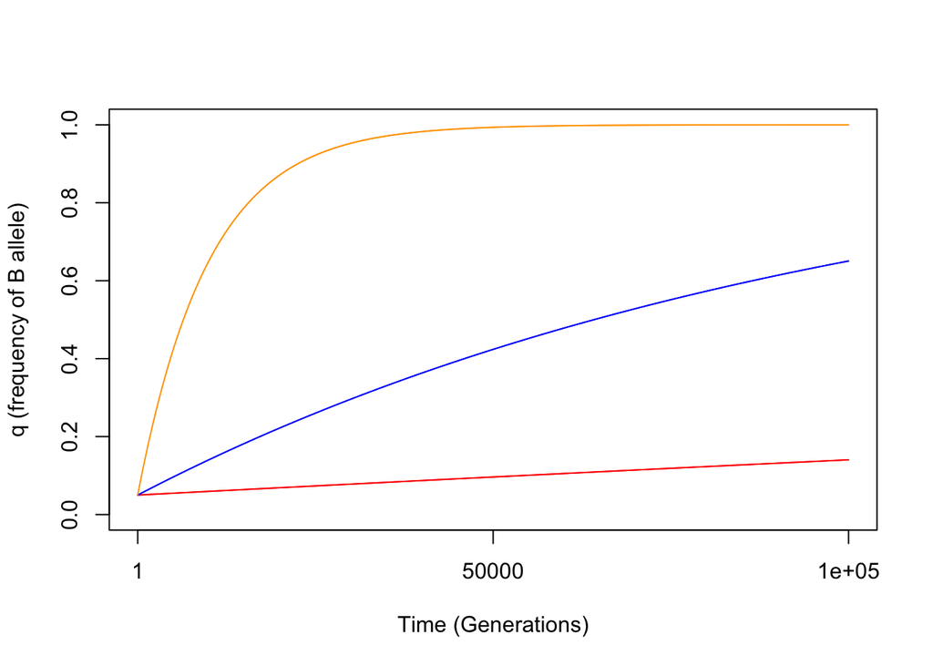

```r
rm(list=ls())
p0 <- 0.95
t <- 1:100000

marks <- c(1,50000,100000)
u <- 0.000001
qt <- 1 - p0*exp(-u*t)
qt5 <- 1 - p0*exp(-0.00001*t)
qt4 <- 1 - p0*exp(-0.0001*t)

plot(x=t, y=qt, xlab="Time (Generations)", ylab="q (frequency of B allele)", type="l", col="red", xaxt="n", ylim=c(0,1))
axis(1,at=marks,labels=marks)
points(x=t,y=qt5,type="l",col="blue")
points(x=t,y=qt4,type="l",col="orange")
```

Finally, we note that this analysis assumes that mutation only occurs in one direction (from A to B). But if there is also back mutation from B to A occurring at rate v, then the allele will never go to fixation. Instead an equilibrium will be reached at:

$$\hat{q} = \frac{u}{u + v}$$

$$\hat{p} = \frac{v}{u + v}$$

# Lecture #4

## Migration

What are the effects of migration on allelic frequency? By migration, we mean the arrival of individuals from another population.

p<sub>0</sub> = initial allele frequency in resident population (changing)

p<sub>m</sub> = allelic frequency in migrant population (constant)

t = time, in number of generations

m = migrant fraction (proportion of the population that consists of new migrants each generation)

1 - m = resident fraction (proportion of population that consists of non-migrants each generation)

To calculate the allelic frequency in the resident population after one generation of migration, we have:

$$p_1 = (1-m)p_0 + (m)p_m$$

More generally, after t generations, the frequency of the allele in the resident population (p<sub>t</sub>)

$$p_t = (1-m)^t(p_0 - p_m) +
p_m$$

## Sample Migration Problem

Given an intial resident frequency p<sub>0</sub> = 0.5, a migrant allele frequency p<sub>m</sub> = 0.9, and the passage of t = 10 generations, the new allelic frequency in the resident population (p<sub>10</sub>) is:

```
p10 = (1 - 0.1)^10 * (0.5 - 0.9) + 0.9 = 0.76
```

So, after only 10 generations, the allele frequency changes from p<sub>0</sub> = 0.50 to p<sub>10</sub> = 0.76. In order for this calculation to hold, all of the other Hardy-Weinberg assumptions need to be in place (no mutation, no selection, large population size, random mating, random segregation of alleles).

## Models Of Genetic Variation

If we examine a random stretch of DNA in an organisms’s genome, how much variation will be present, and how will it be structured?

- `Classical model` Very low genetic variation. Most genes have two homozygous “wild type” alleles (+), with an occasional recessive allele (r) showing up that is usually deleterious. Natural selection operates mostly as purifying selection, removing recessive alleles that are deleterious. This was the view in the early 1900s that emerged from classical genetics, when the only way that “genotypes” could be scored was on the basis of major mutations (which often were deleterious).
- `Balance model` Low genetic variation, but some variants are maintained through `balancing selection` in which the fitness of the heterozygote (AB) is superior to that of either of the two homozygote genotypes (AA or BB). This can happen when the two protein variants expressed in a homozygous individual function optimally at slightly different conditions, which can increase the fitness of an individual in a variable or changing environment. Sickle-cell anemia and resistance to malaria is the classic example.
- `Neutral model` High genetic variation, with many different alleles in the population and many heterozygous loci in different individuals. These kind of alleles have no effect (good or bad) on the fitness of the organism, although in different environments or at some time in the past, they may have fitness consequences.

With modern sequencing methods revealing large amounts of genetic diversity in most species, the consensus view is that the balance and neutral models capture the typical pattern, although of course there are still many examples of deleterious recessive alleles that match the classic model.

## Non-Random Mating

Hardy-Weinberg assumes random mating, but there are a number of different possibilities for how individuals choose mates:

- `random mating` Mate choice is independent of genotype or phenotype
- `positive assortative mating` More frequent matings between similar phenotypes
- `negative assortative mating` more frequent matings between dissimilar phenotypes
- `inbreeding` More frequent matings between relatives

## The Inbreeding Coefficient

The degree of inbreeding can be quantified with the inbreeding coefficient, F

- `inbreeding coefficient` The fractional reduction in heterozygosity relative to a randomly mating population.

$$F = \frac{H_0 - H}{H_0} = 1 -
\frac{H}{H_0}$$

where H is the observed heterozygosity in the population and H<sub>0</sub> is the expected heterozygosity in a Hardy-Weinberg population (2pq).

An equivalent definition comes from the pattern of an individuals predigree:

- `autozygous alleles` Two alleles in an individual that are identical by descent from a single ancestor
- `allozygous alleles` Two alleles in an individual that are identical by descent from two different ancestors
- `inbreeding coefficient (pedigree definition)` The probability that two alleles in an individual are identical by descent (=autozygous)

## Genotype Frequencies Expected With Inbreeding

With these definitions, we can modify the Hardy-Weinberg equation to give the expected genotype frequencies with inbreeding:

| Genotypes | Frequencies | F=0 | F=1 |
| --- | --- | --- | --- |
| AA | p<sup>2</sup>(1 - F) + pF | p<sup>2</sup> | p |
| AB | 2pq(1 - F) | 2pq | 0 |
| BB | q<sup>2</sup>(1 - F) + qF | q<sup>2</sup> | q |

For example, suppose the allele frequencies are p = 0.2, q = 0.8, and F = 0.5. We would have:

```
f(AA) = 0.2^2(1 - 0.5) + 0.2*0.5 = 0.12
f(AB) = 2*0.2*0.8*(1 - 0.5) = 0.16
f(BB) = 0.8^2(1 - 0.5) + 0.8*0.5 = 0.72
```

So, the primary effect of inbreeding is to reduce the frequency of heterozygotes. In the extreme case of full inbreeding, there are no heterozygotes, and we end up with two inbred homozygote lines.

## Costs And Benefits Of Inbreeding

The costs of inbreeding are:

- expression of deleterious recessive alleles (short-term )
- loss of heterozygosity (long-term)

These problems are especially acute for small populations (which are often highly inbred) that may be facing novel environments due to climate change and other factors.

However, there is also an argument that inbreeding could benefit a population by preserving particular genotypes that function well together (= `co-adapted gene complex`).

This effect would be most beneficial for organisms living in stable environments whose offspring do not disperse very far from their parents. Accordingly, there are many examples of restricted plant populations with little or no genetic variability that seem perfectly healthy (at least until the climate changes).

# Lecture #5

## Genetic Drift

Allele frequencies in a population can change from random effects caused by the segregation of alleles into gametes during meiosis. For example, imagine a cross between two heterozygous individuals that produce a total of 400 offspring:

| Genotype | Frequency | Expected Number of Offspring |
| --- | --- | --- |
| AA | 0.25 | 100 |
| AB | 0.50 | 200 |
| BB | 0.25 | 100 |

| Allele | Expected Allele Frequency |
| --- | --- |
| A | 0.50 |
| B | 0.50 |

Of course, by chance, we might not see precisely these numbers. Suppose the counts look like this:

| Genotype | Observed Frequency | Observed Number of Offspring |
| --- | --- | --- |
| AA | 0.2525 | 101 |
| AB | 0.5000 | 200 |
| BB | 0.2475 | 99 |

This deviation has a trivial effect on the allele frequencies:

| Allele | Observed Allele Frequency |
| --- | --- |
| A | 0.5025 |
| B | 0.4975 |

But now imagine the same scenario for a cross that produces only 4 offspring:

| Genotype | Frequency | Expected Number of Offspring |
| --- | --- | --- |
| AA | 0.25 | 1 |
| AB | 0.50 | 2 |
| BB | 0.25 | 1 |

| Allele | Expected Allele Frequency |
| --- | --- |
| A | 0.50 |
| B | 0.50 |

Look what happens this time if the genotype counts are shifted by just one individual:

| Genotype | Observed Frequency | Observed Number of Offspring |
| --- | --- | --- |
| AA | 0.5000 | 2 |
| AB | 0.5000 | 2 |
| BB | 0.0000 | 0 |

This deviation has a huge effect on the allele frequencies:

| Allele | Observed Allele Frequency |
| --- | --- |
| A | 0.75 |
| B | 0.25 |

In this case, the frequency of the A allele has changed from 0.50 to 0.75 in a single generation. Remember that this change will affect all of the descendants of this cross. Even if the population size should return to 400 individuals, this random change in allele frequencies will affect the subsequent evolution of this population.

`genetic drift` random changes in allelic and genotypic frequencies caused by small population size.

You can see from this example that genotypic and allelic changes from genetic drift are much more important in small populations than in large populations. Below a size of roughly 100 individuals, genetic drift becomes very important.

## The Probability of Allele Fixation

`fixed allele` a gene locus that has only a single allele in a population is “fixed” because the allele frequency is 1.00, and every individual in the population is homozygous for the same allele.

Suppose a single new allele arises in a population from mutation. The long-term probability of fixation of this allele is its frequency in the gene pool:

$$p(\mbox{fixation}) =
\frac{1}{2N}$$

Remember that there are 2N alleles in the gene pool for a single gene locus.

However, with mutation rate *u*, each generation there will be 2n*u* copies of the mutant produced. Thus, the long-term probability of fixation is:

$$p(\mbox{fixation}) = \frac{2Nu}{2N} =
u$$

Thus, with mutation and genetic drift, we have the interesting result that the long-term probability of fixation = *u*, the mutation rate of the allele.

As we discussed before, *u* is a small number, so the chances are slim.

In general, if the probability of a single event is small, the overall probability of it occurring at least once can be surprisingly large

$$p(\mbox{single event}) = z$$

$$p(\mbox{no event in one trial}) = 1 -
z$$

$$p(\mbox{no events in t trials}) =(1 -
z)^t$$

$$p(\mbox{at least 1 event in t trials}) =
1 - (1-z)^t$$

This formula applies not to just genetic drift, but to all chance events in life. Suppose for example, that you estimate that the chances of getting a ticket for speeding are 1/100, and you only speed on Friday afternoons (to get home from work quickly to start your weekend).

What are the chances of getting caught speeding at least once during a year in which you work 50 weeks?

```
p(speeding ticket during one year) =

1 - (1 - 0.01)^50 = 0.39
```

So, a 39% chance of getting caught at some time during the year, even though the chance of getting caught each individual Friday is only 0.01.

And if you commute like this for 5 years in a row?

```
p(speeding ticket at least once during 5 years) =

1 - (1 - 0.39)^5 = 0.92
```

A 92% chance you will get caught!

## Effective Population Size

There is an important distinction between the observed population size (N) and the `effective population size`(N<sub>E</sub>):

`effective population size` The equivalent number of individuals in a randomly mating population

In general:

$$N_E < N$$

Why should the effective population size be anything less than the observed population size? There are a number of forces at work that reduce the effective population size by preventing the complete mixing of alleles that we expect in a population that is mating at random. These factors include

- `founder effect` If a population is colonized by only a few individuals (think of islands), the alleles carried by those colonizers will be a small— and often non-random— subset of the larger population they originated from.
- `bottleneck` If a population shrinks back to a small size — even for a single generation — that will reduce the effective population size more than we would expect by calculating a simple arithmetic average of the observed population sizes in consecutive generations. Thus, we can think of the founder effect as a special case of a bottleneck that occurs during colonization.
- `unbalanced sex ratio` If the ratio of males:females in a sexually reproducing population is different from 1:1, the alleles represented by the rarer sex will be disproportionately represented in the next generation.
- `limited natal dispersal` If individuals disperse only a limited distance from where they were born, they will only encounter a limited number of potential mates. Even if they mate randomly, the allelic diversity in this limited spatial “neighborhood” is less than that of the entire population.

Let’s look at some simple equations for calculating N<sub>E</sub> under these circumstances

## Effective Population Size With A Bottleneck

If observed population size n<sub>i</sub> changes in each of t consecutive generations:

$$\frac{1}{N_E} = \frac{1}{t}
(\frac{1}{n_1}+ \frac{1}{n_2}+ \frac{1}{n_3}+ \frac{1}{n_4}+\dots+
\frac{1}{n_t})$$

For example, suppose the observed population size of a population of orchids is 100,4,100,100,100, undergoing a bottleneck in generation 2, but then fully recovering in subsequent generations. For this sequence, N<sub>E</sub> is calculated as:

```
1/N_E = 1/5(1/100 + 1/4 + 1/100 + 1/100 + 1/100)
1/N_E = 1/5(1//100 + 1/4 + 1/100 + 1/100 + 1/100)
1/N_E = 1/5(1/100 + 25/100 + 1/100 + 1/100 + 1/100)
1/N_E = 1/5(29/100)
1/N_E = (29/500)
N_E = (500/29) = 17.24 individuals
```

## Effective Population Size With An Unbalanced Sex Ratio

Alleles will be thoroughly mixed in a randomly mating population with equal numbers of males and females. However, if the sex ratio is skewed strongly from 1:1, the allelic diversity will be limited by the rarer sex and the alleles that it is collectively carrying. If the population consists of N<sub>M</sub> males and N<sub>F</sub> females, the effective population size (N<sub>E</sub>) is:

$$N_E = \frac{4N_M N_F}{N_M + N_F}$$

For example, if the population consists of 100 females and only 10 males, the effective population size is:

```
N_E = (4)(100)(10)/(100 + 10)

N_E = 4000/110 = 36.4 individuals
```

Notice that although the observed population size (N) is 110 individuals, the effective population size (N<sub>E</sub>) is only 36.4, which is small enough for genetic drift to become important.

## Effective Population Size With Limited Natal Dispersal

For complete mixing of aleles, an individual would need to be able to mate randomly with any other individual in its population. More realistically, an individual is much more likely to mate with neighboring individuals that are close by and much less likely to mate with individuals that are distant. Under these circumstances, the effective population size is calculated as:

$$N_E = 4\pi dx$$

where d is the population density (individuals/area), and x is the dispersal distance from where an individual is born to where it mates. With limited dispersal and/or a population that is at low density, individuals are likely to choose mates from only a limited “neighborhood” of nearby individuals. Even with random mating, the effect of this is to reduce the local genetic diversity in each of the neighborhoods. Limited dispersal introduces a kind of “viscosity” to the population that can make genetic drift important.

As a simple example, if the density of individuals is 10 per m<sup>2</sup>, but the dispersal distance is only 1 m, the effective population size is:

```
N_E = 4*pi*10*1

N_E =125.6 individuals
```

In summary, genetic drift is an important force in changing allele frequencies when effective population sizes are less than 100, and there are a number of common features of populations (bottlenecks, biased sex ratios, and limited dispersal) that can lower N<sub>E</sub> below this threshold.

## Summary Of The Effects Of Four Potential Mechanisms Of Evolution

| Mechanism | Change in Allele Frequency? | Change in Genotype Frequency? |
| --- | --- | --- |
| Mutation | Yes (unlikely) | Yes (unlikely) |
| Migration | Yes | Yes |
| Non-random Mating | No (yes with recessive lethals) | Yes |
| Genetic Drift | Yes (if N<sub>E</sub> < 100) | Yes (if N<sub>E</sub> < 100) |

| Mechanism | Strength of Change? | Lead to Fixation? | Predictable? |
| --- | --- | --- | --- |
| Mutation | Weak | Yes (no with back mutation) | Yes |
| Migration | Strong | Yes | Yes |
| Non-random Mating | Weak | No (yes with recessive lethals) | Yes |
| Genetic Drift | Strong (if N<sub>E</sub> < 100) | Yes (if N<sub>E</sub> < 100) | No |

# Lecture #6

## Definitions

`natural selection (popular definition)` “survival of the fittest”

`natural selection (biological definition)` differential reproduction and/or survival of individuals with heritable traits

`tautology` a self-referencing definition

## Assumptions of Natural Selection

1. Individuals exhibit variation in their traits
2. At least some of that variation has a heritable (= genetic) component
3. All individuals produce more offspring than can survive
4. Particular traits enhance survival in particular environments (relative to individuals with other traits)

## Selection Experiments And The Measurement Of Fitness

- establish an experiment with replicate individuals of each genotype in the population (there will be 3 such genotypes AA AB BB for a single-gene two-allele system)
- expose individuals to a selection pressure (e.g. heat shock, presence of a predator, disease)
- calculate the number surviving after the selection pressure (or their reproduction in a fecudity experiment)
- calculate absolute fitness as the proportion that survive (p<sub>1</sub>, p<sub>2</sub>, p<sub>3</sub>)
- calculate relative fitness by dividing absolute fitness by the absolute fitness of the “best” genotype (w<sub>1</sub>, w<sub>2</sub>, w<sub>3</sub>)
- assume the environment is constant, so that the relative fitness values are the same in each generation

`absolute fitness` proportional survival or relative reproduction of genotypes in a selection experiment

`relative fitness` absolute fitness values scaled to the largest absolute fitness measured for one of the genotypes in the population

| Genotype | Before Selection | After Selection | Absolute Fitness | Relative Fitness |
| --- | --- | --- | --- | --- |
| AA | 50 | 20 | 20/50=0.4 | 0.4/0.4 = 1.0 |
| AB | 100 | 35 | 35/100=0.35 | 0.35/0.40 = 0.875 |
| BB | 25 | 5 | 5/25=0.20 | 0.20/0.40 = 0.50 |

w<sub>1</sub> = 1.0 = relative fitness of AA  
w<sub>2</sub> = 0.875 = relative fitness of AB  
w<sub>3</sub> = 0.50 = relative fitness of BB

`mean fitness` average fitness of individuals in the population after random mating and selection $= \bar{w}$

$$\bar{w} = p^2w_1 + 2pqw_2 +
q^2w_3$$

## A Model Of Natural Selection & Random Mating

### STEP #1. Given: initial genotype counts AND relative fitness values

$$\#AA$$
$$\#AB$$
$$\#BB$$

$$w_1 = \frac{\mbox{absolute fitness of
AA}}{\mbox{largest maximum fitness}}$$

$$w_2 = \frac{\mbox{absolute fitness of
AB}}{\mbox{largest maximum fitness}}$$

$$w_3 = \frac{\mbox{absolute fitness of
BB}}{\mbox{largest maximum fitness}}$$

```
AA = 50       AB = 50        BB = 100

w_1 = 0.40/0.40 = 1.00
w_2 = 0.35/0.40 = 0.875
w_3 = 0.20/0.40 = 0.50
```

### STEP #2. Calculate initial genotype and allelic frequencies (p<sub>0</sub>, q<sub>0</sub>)

$$f(AA) = \frac{\#AA}{N} \; f(AB) =
\frac{\#AB}{N} \; f(BB) = \frac{\#BB}{N}$$

$$f(A) = f(AA) + \frac{1}{2}f(AB) = p_0$$

$$f(B) = f(BB) + \frac{1}{2}f(AB) = q_0$$

```
f(AA) = 50/200  = 0.25
f(AB) = 50/200  = 0.25
f(BB) = 100/200 = 0.50

f(A) = 0.25 + (0.5)*(0.25) = 0.375 = p_0
f(B) = 0.50 + (0.5)*(0.25) = 0.625 = q_0
```

### STEP #3. Calculate genotype frequencies AFTER random mating

$$f(AA)=p_0^2$$

$$f(AB)= 2p_0q_0$$

$$f(BB)=q_0^2$$

```
f(AA) = (0.375)^2 = 0.141
f(AB) = 2(0.375)(0.625) = 0.469
f(BB) = (0.625)^2 = 0.391
```

### STEP #4. Calculate genotype frequencies AFTER selection

$$p_0^2w_1 + 2p_0q_0w_2 + q_0^2w_3 =
\bar{w}$$

```
f(AA) = (0.141)(1.0) = 0.141
f(AB) = (0.469)(0.875) = 0.410
f(BB) = (0.391)(0.50) = 0.196

mean fitness = 0.141 + 0.410 + 0.196 =  0.747
```

### STEP #5. Normalize genotype frequencies

$$f(AA)=\frac{p_0^2w_1}{\bar{w}}$$

$$f(AB)= \frac{2p_0q_0w_2}{\bar{w}}$$

$$f(BB)= \frac{q_0^2w_3}{\bar{w}}$$

```
f(AA) = 0.141/0.747 = 0.189
f(AB) = 0.410/0.747 = 0.549
f(BB) = 0.196/0.747 = 0.262
```

### STEP #6. Calculate new allelic frequencies

$$f(A) = f(AA) + \frac{1}{2}f(AB) = p_1$$

$$f(B) = f(BB) + \frac{1}{2}f(AB) = q_1$$

```
f(A) = 0.189 + 0.5*(0.549) = 0.464 = p_1

f(B) = 0.262 + 0.5*(0.549) = 0.536 = q_1
```

### STEP #7. Calculate new genotype frequencies AFTER random mating

$$f(AA)=p_1^2$$

$$f(AB)= 2p_1q_1$$

$$f(BB)=q_1^2$$

```
f(AA) = (0.464)^2 = 0.215
f(AB) = 2(0.464)(0.536) = 0.497
f(BB) = (0.536)^2 = 0.287
```

# Lecture #7

## Long-term Outcomes Of Selection

`Selection coefficient s` measure of relative selection *against* a genotype

$$s = 1 - w$$

s = 0 (no relative loss to selection = best genotype = w = 1)  
s = 1 (lethal genotype w = 0)

| Selection Scenario | w<sub>1</sub> | w<sub>2</sub> | w<sub>3</sub> | Result |
| --- | --- | --- | --- | --- |
| against recessive | 1.0 | 1.0 | 1 - s<sub>3</sub> | Slow elimination of (a) allele |
| against recessive + mutation | 1.0 | 1.0 | 1 - s<sub>3</sub> | equilibrium $q \approx \sqrt{(u/s)}$ |
| against dominant | 1 - s<sub>1</sub> | 1 - s<sub>2</sub> | 1.0 | rapid elimination of (A) allele |
| favoring heterozygote | 1 - s<sub>1</sub> | 1.0 | 1 - s<sub>3</sub> | equilibrium $q = s_1/(s_1 + s_3)$ |

## What Does Natural Selection Maximize?

`Fisher's Fundamental Theorem Of Natural Selection` Natural selection maximizes the average fitness $(\bar{w})$ in a population.

If there is selection against a dominant or against a recessive, this leads to allele fixation with $\bar{w} = 1$. If there is selection against a recessive with ongoing mutation or selection favoring the heterozygote (= `heterosis` or `balancing selection`) both alleles are maintained at an equilibrium, and $(\bar{w})$ is maximized at a value less than 1.0.

## The Modern Synthesis

1. **Evolutionary phenomena** (genetic change in populations, adaptation, speciation) can be explained via mechanisms consistent with Mendelian genetics.
2. **Evolution is gradual** via small genetic changes; as these changes accumulate, species diverge.
3. **Natural selection is the strongest mechanism** of evolution, and may work in concert with genetic drift.
4. **Genetic diversity** in populations reflects past and current natural selection.
5. **Microevolutionary change** leads to macroevolutionary responses.

# Lecture #8

## Selection On Quantitative Traits

Most traits in nature are not controlled by a single gene with multiple loci. Many traits are controlled by multiple loci and can also reflect phenotypic plasticity and environmental effects. These traits, such as body size, usually exhibit a bell-shaped normal distribution. In this lecture we describe a simple theoretical framework for thinking about the evolution of these traits, and then consider three experimental designs (artificial selection, common garden, reciprocal transplant) to tease apart environmental and genetic effects on continuous traits.

`discrete trait` a trait that takes on only a limited number of discrete values (e.g. red, purple, or white feathers). These traits are often controlled by a single Mendelian gene with a few alternative loci.

`continuous trait` a trait (such as body mass) that can exhibit a continuous range of values. These traits are often controlled by several genes with small additive effects, and are often phenotypically plastic, so that their expression also depends on environmental conditions.

## Models Of Selection On Continuous Traits

`directional selection` Individuals with the largest value of a trait have higher fitness than individuals with intermediate or small trait values. Over time, the average trait value will increase, but there will probably be no change in the trait variance. Depending on the particular trait, directional selection could work on the smallest value of a trait in just the same way. Directional selection may be important in changing environments, such as increasing global temperatures, because it will favor those individuals with extreme traits (e.g. heat tolerance) that confer higher fitness under new conditions.

`stabilizing selection` Individuals with intermediate values of the trait have higher fitness than individuals with extremely large or extremely small trait values. Over time, the average trait value does not change, but the variance in the trait will decrease because the individuals with the most extreme trait values will have lower fitness. Stabilizing selection is common in stable environments, where a single optimal phenotype (such as body size or offspring production) maximizes individual fitness.

`disruptive selection` Individuals with extreme trait values (large or small) have higher fitness than individuals with intermediate trait values. Over time, the average trait value will not change, but the variance should increase, possibly leading to a bimodal distribution of traits. This kind of selection is uncommon, but can be seen when individuals colonize new habitats where they are rapidly exposed to extreme conditions. One example (which we will discuss) is the evolution of plant tolerances to heavy metals in contaminated soils.

## Artificial Selection Experiments

We humans have been conducting selective breeding experiments— both consciously and unconsciously— on plants and animals for thousands of years, and they yielded everything from fast-growing varieties of wheat to noble dog breeds like the chow-chow. Artificial selection experiments also gave Darwin the critical insight that environmental conditions in nature could impose a similar kind of natural selection on populations that would cause populations to evolve and eventually form new species.

The method is simple:

$$\bar{x} = \mbox{mean of trait in
parental stock (before selection and before breeding)}$$
$$\bar{y} = \mbox{mean of trait in parental stock
(after selection and before breeding)}$$
$$\bar{z} = \mbox{mean of trait in parental stock
(after selection and after breeding)}$$

$$S = \mbox{Selection Differential} =
\bar{y} - \bar{x}$$
$$R =
\mbox{Response To Selection} = \bar{z} - \bar{x}$$
$$\mbox{heritability} = h^2 =
\frac{R}{S}$$

`heritability` the proportion of total variation among individuals in a continuous trait that can be attributed to genetic differences among individuals. Note that $0.0 \le p \le 1.0$.

```
x = 10
y = 20
z = 11

S = selection differential = 20 - 10 = 10
R = response to selection = 11 - 10 = 1
h^2 = heritability = R/S = 1/10 = 0.10
```

# Lecture #9

## Common Garden Experiments

There are statistically significant differences in the trait values (the phenotype) between these populations, and we want to understand if these are caused by differences in the genotypes in the 3 populations, or differences in the environment in the 3 locations.

### Common Garden Trait Distribution With Pure Genetic Effects

The organisms are transplanted into a common garden (either in the lab or in the field) so they all experience the same environmental conditions. We further assume that the trait is not influenced by maternal effects (such as the condition of the mother during the development of the embryo) or early environment effects (such as nutrition and diet of the organism during early growth).

In this case, it looks like there is a strong genetic component to the trait, because the differences observed in the natural populations are also found when the organisms from each population are raised in the common garden experiment:

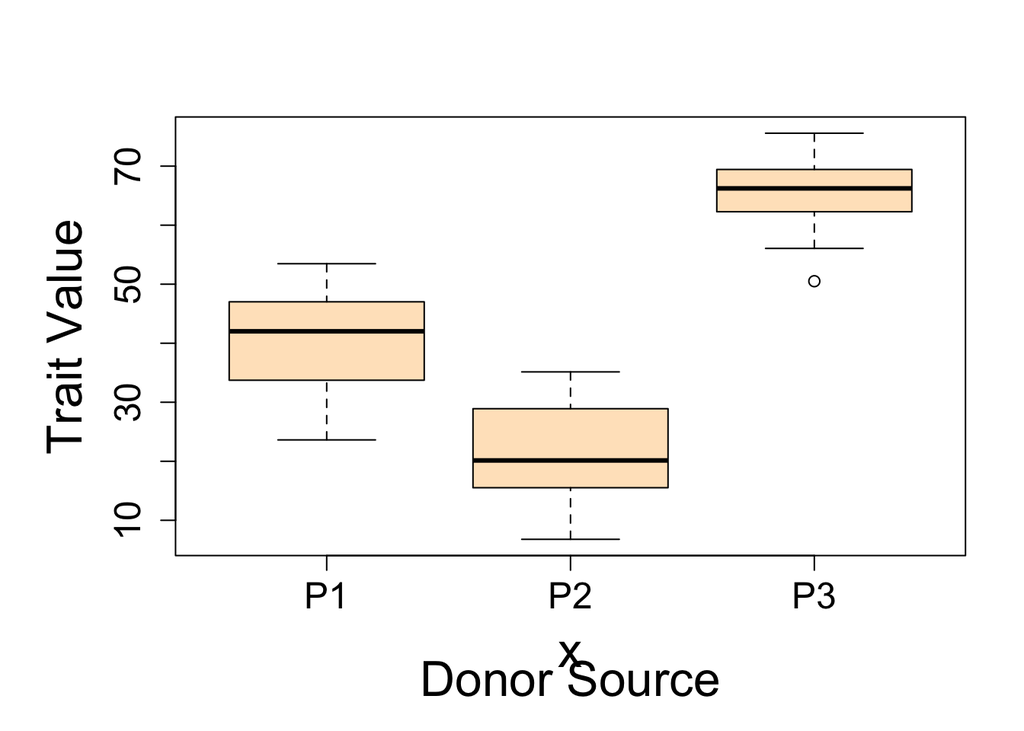

When we find this result, we say that the different populations represent different *ecotypes*.

`ecotype` Genetically distinct geographic varieties from different local populations.

### Common Garden Trait Distribution With Pure Environmental Effects

Another scenario is that the trait distributions in the common garden experiment are not statistically different from one another. In this case, the traits values are approximately the same for individuals sampled from different populations. This results suggests that the phenotypic differences observed in nature reflect differences in the environment that each population experiences. The populations do not show evidence for genetic differentiation (at least with respect to this trait), and thus they do not represent different ecotypes. Note that the results of the common garden experiment may depend on the kind of environment that is used in the common garden. We explore this issue more carefully with a reciprocal transplant experiment.

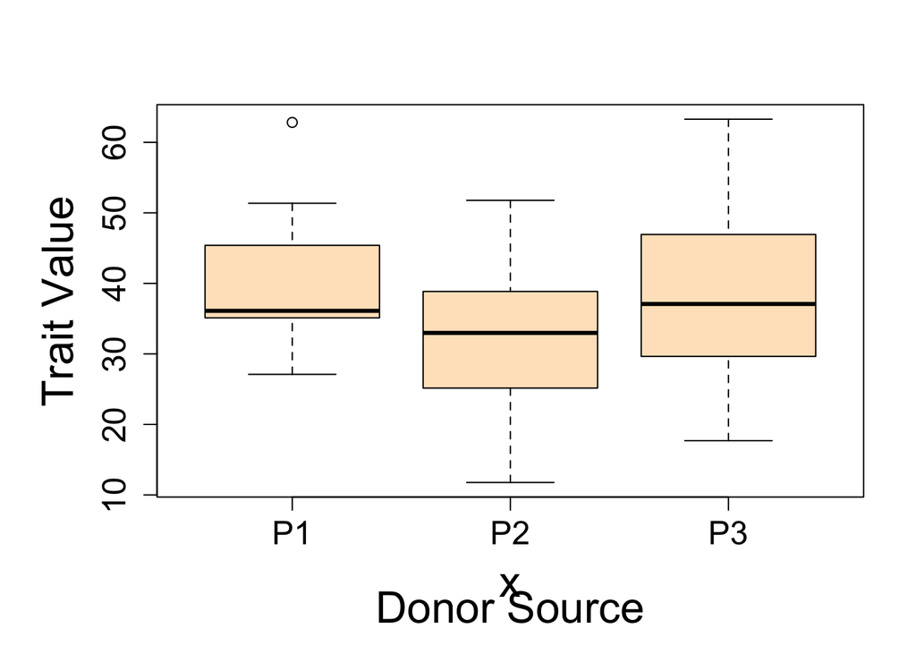

## Reciprocal Transplant Experiment

A reciprocal transplant experiment is like a common garden experiment, but it is done in the field, and there are two transplant sites, representing the locations where the two populations originated. Two additional “control” treatments are established by transplanting individuals back into the site from which they were collected. This treatment controls for any effects of handling or transport on the expression of the trait. Because there are two populations from which individuals are transplanted, and two sites into which they are transplanted, this is a “crossed” or “orthogonal” experimental design.

In the diagrams below, the table and figure illustrate the mean value of the trait measured in each of the 4 treatments, and the table of statistical tests gives results for additive effects of genotype, additive effects of environment, and the genotype by environment interaction term.

### Scenario 1: No Effects of Genotype Or Environment On Average Trait Values

|  | Donor Population (Cold) | Donor Population (Warm) |
| --- | --- | --- |
| Recipient Site (Cold) | 10 | 10 |
| Recipient Site (Warm) | 10 | 10 |

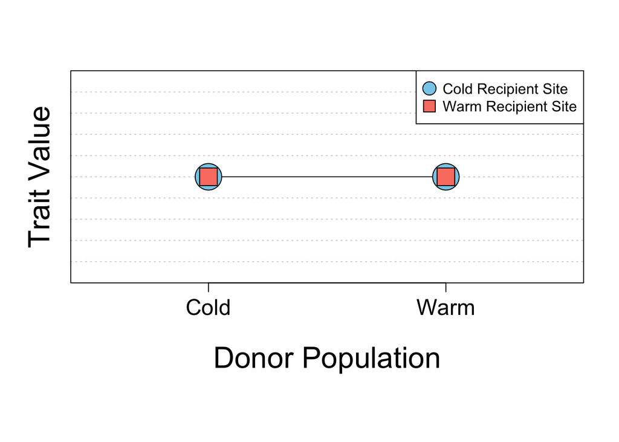

| Statistical Test | *P*-value |
| --- | --- |
| Genotype Effect (Additive) | N.S. |
| Environment Effect (Additive) | N.S. |
| Genotype x Environment (Interaction) | N.S. |

### Scenario 2: Environmental Effects On Average Trait Values

|  | Donor Population (Cold) | Donor Population (Warm) |
| --- | --- | --- |
| Recipient Site (Cold) | 20 | 20 |
| Recipient Site (Warm) | 10 | 10 |

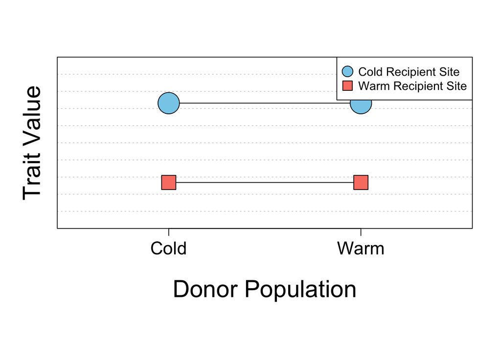

| Statistical Test | *P*-value |
| --- | --- |
| Genotype Effect (Additive) | N.S. |
| Environment Effect (Additive) | *P* < 0.05 |
| Genotype x Environment (Interaction) | N.S. |

### Scenario 3: Genotype Effects On Average Trait Values

|  | Donor Population (Cold) | Donor Population (Warm) |
| --- | --- | --- |
| Recipient Site (Cold) | 20 | 10 |
| Recipient Site (Warm) | 20 | 10 |

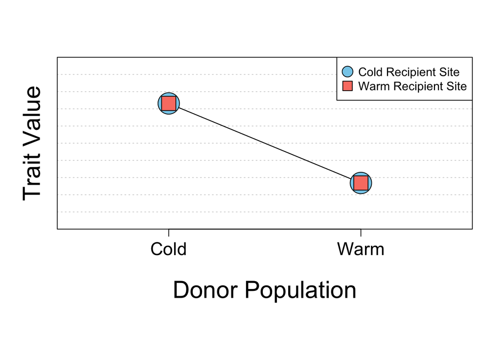

| Statistical Test | *P*-value |
| --- | --- |
| Genotype Effect (Additive) | *P* < 0.05 |
| Environment Effect (Additive) | N.S. |
| Genotype x Environment (Interaction) | N.S. |

### Scenario 4: Genotype And Environment Effects (Additive) On Average Trait Values

|  | Donor Population (Cold) | Donor Population (Warm) |
| --- | --- | --- |
| Recipient Site (Cold) | 20 | 5 |
| Recipient Site (Warm) | 25 | 10 |

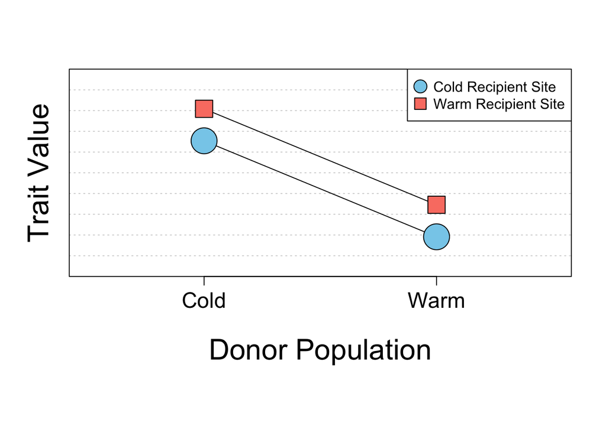

| Statistical Test | *P*-value |
| --- | --- |
| Genotype Effect (Additive) | *P* < 0.05 |
| Environment Effect (Additive) | *P* < 0.05 |
| Genotype x Environment (Interaction) | N.S. |

### Scenario 5: Genotype by Environment Interaction Effect On Average Trait Values

|  | Donor Population (Cold) | Donor Population (Warm) |
| --- | --- | --- |
| Recipient Site (Cold) | 20 | 50 |
| Recipient Site (Warm) | 15 | 10 |

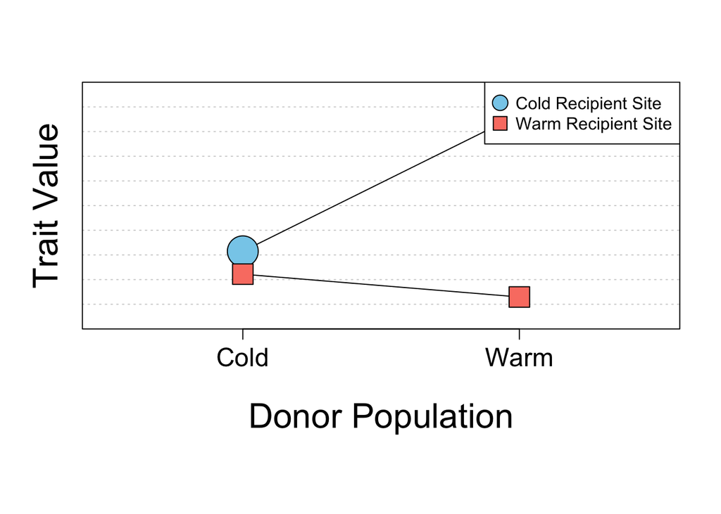

| Statistical Test | *P*-value |
| --- | --- |
| Genotype Effect (Additive) | N.S. |
| Environment Effect (Additive) | N.S. |
| Genotype x Environment (Interaction) | *P* < 0.05 |

When the interaction term is significant, the lines connecting the treatments are no longer parallel. We can describe this interaction by saying that the difference in trait values between genotypes depends on the environment. Equivalently, we could say that the difference in trait values between environments depends on the genotype. Statistical interactions of this sort make it hard to predict the joint effect of two factors (in this case environment and genotype) just knowing how each one operates in isolation. Strong interactions between prescription drugs are a common example of this problem.

# Lecture #10

`species (biological definition)` Groups of actually or potentially interbreeding populations that are *reproductively isolated* from other such groups.

`species (taxonomic definition)` Populations that can be reliably distinguished on the basis of one or more morphological/genetic characters.

|  | Morphologically Distinct | Not Morphologically Distinct |
| --- | --- | --- |
| Reproductively Isolated | “good” species | cryptic species |
| Not Reproductively Isolated | variable populations | similar populations |

## Pre-Mating Isolating Mechanisms

1. Seasonal, habitat isolations (individuals do not meet)
2. Ethological isolation (individuals meet, but do not mate)
3. Mechanical isolation (gamete transfer not possible)

## Post-Mating Isolating Mechanisms

1. Gamete Mortality
2. Zygote Mortality
3. Hybrid Mortality
4. Hybrid Sterility

If post-mating isolating mechanisms are present, then natural selection will favor the evolution of pre-mating mechanisms.

## Geographic Mechanisms of Speciation

1. Allopatric Speciation
   - widespread taxon
   - emergence of a dispersal barrier
   - differentiation and reproductive isolation on each side of the barrier
2. Peripheral Isolates Speciation
   - widespread taxon
   - pre-existing dispersal barrier
   - occasional dispersal across barrier
   - rapid differentiation and reproductive isolation of the peripheral population before additional dispersal and gene flow occur
3. Sympatric Speciation
   - widespread taxon
   - reproductive isolation of local population without geographic isolation
   - mechanisms include major mutations, polyploidy, strong habitat differentiation

## Frequency of Geographic Speciation Mechanisms

|  | Allopatric | Peripheral Isolates | Sympatric |
| --- | --- | --- | --- |
| Vertebrates | 80% | 15% | 5% |
| Plants | 20% | 20% | 60% |

## Reconstructing Evolutionary Relationships

- root of tree = ancestor (from a starting point)
- time = moves in vertical direction in tree diagram
- branch tip = contemporary species
- branch fork = speciation event

`dichotomy` tree is drawn with single branch forks  
`polytomy` multiple simultaneous branch points (with more data, these are usually resolved into a series of dichotomous branches)  
`sister species` two species sharing a most recent common ancestor  
`sister taxa` any groups on a tree sharing a most recent common ancestor  
`monophyletic group` an ancestor and all of its descendants  
`polyphyletic group` an incorrect classification or grouping that is not monophyletic  
`synapomorphy` shared derived characters uniting monophyletic groups  
`homoplasy` independent or convergent evolution of the same character state in unrelated lineages

## Steps In Reconstructing Relationships Among Species

1. Select traits with alternative states that vary among contemporary species.
2. Measure and record traits for each species.
3. Code each state of a trait as either ancestral(0) or derived(1).
4. Specify alternative evolutionary trees (= hypotheses).
5. Map character state changes onto each possible evolutionary tree.
6. Choose among trees by minimizing the number of character state changes needed to reconstruct the current trait distribution (= parsimony).

# Lecture #11

`sex` The recombination of alleles with those of another individual via meiosis and fertilization. Reproduction can occur without sex (e.g. plant grafts, and parthenogenesis). Sex can even occur without reproduction (e.g. *Paramecium*, which undergo conjugation and exchange genetic material without reproducing). Some organisms like aphids alternate between sexual and asexual reproduction.

## Evolutionary Costs of Sex

1. Costs of time and energy
2. Risk of predation
3. Risk of sexually transmitted diseases
4. 50% reduction in fitness (2N -> N) compared to asexual reproduction (2N -> 2N)

## Evolutionary Benefits of Sex

1. Avoidance of Muller’s Ratchet (= accumulation of deleterious alleles in an asexually reproducing lineage
2. Enhanced DNA repair when two copies of DNA are available.
3. Remixing of alleles may help hosts in a co-evolutionary arms race with rapidly evolving microbial parasites (viruses and bacteria).
4. Sexual reproduction generates genetic variation in offspring (probably the most important benefit).

## Underlying Biological Difference Between Males and Females

Males produce a tiny gamete (sperm), whereas females produce a large gamete (egg). All other differences between males and females are secondary sexual characteristics. Although both sexes make equal genetic contributions to offspring, the energetic investment of females per gamete may be 100 to 1000 fold greater than for males.

## How Did Differences In Gamete Size Evolve In The First Place?

1. Stabilizing selection for optimal zygote size.
2. Disruptive selection for gamete size (large or small is best).
3. Negative assortative mating based on gamete size.

## Sexual Selection & The Different Male And Female Reproductive Strategies

`male strategy` gametes are inexpensive so making a “mistake” and choosing a mate with low-fitness alleles is not costly. Strategy should be to maximize the number of matings.

`female strategy` gametes are expensive so making a “mistake” and choosing a mate with low-fitness alleles is costly. Strategy should be to maximize the quality of matings.

`Bateman's Principle` Sexual selection should be strongest on males, who are competing for females.

The two predictions of Bateman’s Principle are:

1. The variance in reproductive success of males should be much higher than that of females.
2. In males, the number of offspring produced rises much more steeply with the number of matings than in females.

Both predictions have been repeatedly confirmed. In pipe fish, the pattern is opposite that of prediction (2), but that is because male pipefish carry the eggs and provide parental care of the young.

## Male-Male Competition

Males compete among themselves for resources, for females, and for selection as mates by females.

1. Large body size and specialized structure for combat with other males. In invertebrates without viviparity, females may be larger than males. This evolves under conditions of low density, and perhaps represents a form of scramble competition for males to achieve higher reproductive success with rapid development and a small body size.
2. Alternative mating strategies (in sunfish, alpha males, streaker males, sneaker males).
3. Sperm competition (post-copulatory plugs, pheremone release, removal of competing sperm).
4. Infanticide (male lions kill the cubs when they invade a new pride).

## Female Choice

Females may choose males based on a number of factors that will enhance their fitness.

1. Better genes hypothesis. Females choose males based on traits that are directly linked to fitness (e.g. bright color, carotenoids, and parasite resistance in guinea fowl).
2. Acquisition of resources (food for female and for her offspring; scorpion flies, song birds).
3. Handicap principle (males with “costly” appendages may have extra energy reserves and produce high-fitness offspring).
4. Runaway sexual selection (peacock tail feathers, Irish elk antlers). This is eventually halted by natural selection, especially for predation risk (guppy ornamentation in ponds with and without predators).

# Lecture #12

## The Paradox Of Altruism

`altruism` individuals enhance the fitness of others at the expense of their own fitness.

|  | Actor Benefits | Actor is Harmed |
| --- | --- | --- |
| Recipient Benefits | Cooperation | Altruism |
| Recipient is Harmed | Selfishness | Spite |

Because natural selection will favor individuals that successfully pass on their own alleles, how can altruistic behavior ever evolve?

`group selection` Groups of individuals that engage in altruistic behavior will outperform groups that engage in selfish behavior.

This argument is invoked when it is claimed that altruism is favored “for the good of the species”. But an altruistic group is always vulnerable to invasion by a cheating individual, whose own fitness will always be higher than the others in a group of altruists. For similar reasons, it is difficult for sellers to maintain an economic cartel because rivals can always undercut them by selling at cheaper prices.

## Kin Selection

The evolutionary biologist William Hamilton proposed kin selection as a general solution to how altruism might evolve. The key to kin selection is recognizing that individuals in a population share alleles not only with their offspring, but with other relatives.

`kin selection` Selection favoring the spread of allele copies in related individuals.

Altruistic behavior can spread through a population when

$$Br - c > 0$$

B = benefit to the recipient  
c = cost to the actor  
r = degree of relatedness

`r(degree of relatedness)` The probability that 2 alleles in 2 different individuals are shared by descent.

Note that this definition of `r` is very similar to the definition of the inbreeding cofficient F, which is the probability that two alleles *in a single individual* are shared by descent.

To calculate r, draw the arrows of relationship connecting the actor and recipient and indicate the proportion of shared alleles for each step. Next multiply the proportions for each unique path and sum the paths together.

### Relatedness of two full siblings

$$r =
\left(\frac{1}{2}\right)\left(\frac{1}{2}\right) +
\left(\frac{1}{2}\right)\left(\frac{1}{2}\right) = 0.50$$

### Relatedness of two half siblings

$$r =
\left(\frac{1}{2}\right)\left(\frac{1}{2}\right) = 0.25$$

### Relatedness of two cousins

$$r =
\left(\frac{1}{2}\right)\left(\frac{1}{2}\right)\left(\frac{1}{2}\right)
= 0.125$$

When the evolutionary biologist Haldane saw these calculations, he declared

> “I would lay down my life for two of my brothers or eight of my cousins!”

## Kin selection in White-Throated Bee-eaters

These African birds nest in colonies of 40-150 individuals and interact within smaller subgroups of 3-17 birds. The individuals are highly cooperative. They share in colony defense, food-gathering, and cooperative rearing of young. Some females will post-pone reproduction to care for the young of others. However, a careful analysis of genetic paternity revealed that altruistic behaviors are preferentially directed towards relatives:

| r | Expected Frequency of Helping | Observed Frequency of Helping |
| --- | --- | --- |
| 1/2 | 0.17 | 0.41 |
| 1/4 | 0.30 | 0.40 |
| 0 | 0.35 | 0.15 |

These observations confirm the basic prediction of kin selection, which is that altruism should be directed towards individuals who are related and share alleles.

## Eusociality

This behavior has evolved most commonly in the insect order Hymenoptera. Within the hymenoptera, all the ants are eusocial, as are some of the wasps and some of the bees. Elsewhere in the animal kingdom, eusociality has evolved in the termites and the naked mole rats. Within the Hymenoptera, eusociality has evolved at least 9 times in independent lineages.

Why is eusociality so common in the Hymenoptera? One clue is their strange system of sex determination

`haplodiploidy` Sex determination system of the hymenoptera in which fertilized eggs develop into females and unfertilized eggs develop into males.

Haplodiploidy does some unusual things to patterns of relatedness.

For example, the degree of relatedness between a mother and her daughter is the same as for other organisms

$$r =
\left(\frac{1}{2}\right)$$

But now consider the degree of relatedness between two sisters:

$$r =
\left(\frac{1}{2}\right)\left(\frac{1}{2}\right) +
\left(\frac{1}{2}\right)\left(1\right) = 0.75$$

Thus, females share more alleles with their sisters than they do with their own daughters! Therefore, kin selection predicts that some females should forego their own reproduction to assist their mother in raising more sisters. That is exactly what happens in ants and eusocial wasps and bees: all of the worker castes are female.

The situation is different for males. They share all of their alleles with their daughters:

$$r = 1$$

but they share only $1/4$ of their alleles with their sisters:

$$r =
\left(\frac{1}{2}\right)\left(\frac{1}{2}\right) +
\left(0\right)\left(\frac{1}{2}\right)\ = 0.25$$

Here kin selection theory predicts that males should be selfish, contribute nothing to colony maintenance, and invest only in mating. Again, that is exactly what happens.

But there are two complications to this “just-so” story:

1. Not all Hymenoptera are eusocial. There are many species of solitary wasps and bees that are haplodiploid, but don’t have sterile worker castes. Why not?
2. Naked mole rats and termites are also eusocial, but they are not haplodiploid and have normal sex determination with fertilized eggs devloping into both males and females. So why are they eusocial?

One interesting observation is that termites, nakes mole rats, and many species of ants, wasps, and bees all live in the ground. If you are burrowing through soil and meet another individual face to face, there may be a strong incentive for cooperation rather than fighting or fleeing. Perhaps this is an ecological set of conditions that favors cooperation and perhaps serves as a precursor the evolution of eusociality in these animals.

# R Functions

Here is a collection of R functions that calculate each of the formulas we use in BCOR 102. You can paste them into R or use in the accompanying script file `BCOR_LECTURE_NOTES.R`. These are simple calculators that you can use to practice numerical problems and make sure you are doing your calculations correctly.

## R Functions For Allelic & Hardy-Weinberg Calculations

1. `AlleleFreq_2A` takes as inputs the number or frequencies of 3 genotypes (AA AB BB) and returns the frequencies of the two alleles (A B)
2. `AlleleFreq_3A` takes as inputs the number or frequencies of 6 genotypes (JJ JK KK KL KK LL) and returns the frequencies of the three alleles (J K L)
3. `HardyWeinberg_2A` takes as inputs the frequencies of two alleles (A B) and returns the frequencies of the three genotypes at equilibrium (AA AB BB).
4. `HardyWeinberg_3A` takes as inputs the frequencies of two alleles (J K L) and returns the frequencies of the three genotypes at equilibrium (JJ JK KK KL KK LL).

```r
# FUNCTION to calculate observed allele frequencies or a single gene with 2 alleles
# NJG
# 21 November 2015

AlleleFreq_2A <- function(x=c(AA=100, AB=50, BB=50)) {

  # Pull out counts of individual genotypes
  AA <- x[1]
  AB <- x[2]
  BB <- x[3]
  # Create a vector and divide by the sum; works for frequencies or raw counts as input
  Gen_Freq <- c(AA,AB,BB)/sum(AA + AB + BB)

  # Print genotype frequencies
  cat("Observed genotypic frequencies:", "\n","freq(AA) = ", Gen_Freq[1], "\n", "freq(AB) = ", Gen_Freq[2], "\n", "freq(BB) = ", Gen_Freq[3],"\n")
  cat("\n")

  # Create vector for allele frequencies
  Allele_Freq <- vector("numeric",2)

  # Use genotypes to calculate allele frequencies
  Allele_Freq[1] <- Gen_Freq[1] + 0.5*Gen_Freq[2]
  Allele_Freq[2] <- Gen_Freq[3] + 0.5*Gen_Freq[2]

  # Print allelic frequencies
  cat("Observed allelic frequencies:", "\n", "freq(A) = ", Allele_Freq[1], "\n", "freq(B) = ", Allele_Freq[2], "\n")
  cat("\n")
  # Return the output vector
  return(Allele_Freq)
}
```

```r
# FUNCTION to calculate observed allele frequencies or a single gene with 3 alleles
# NJG
# 21 November 2015

AlleleFreq_3A <- function(x=c(JJ=100, JK=50, JL=50, KL=50, KK=50, LL=50)) {

  # Convert input vector to individual genotypes
  JJ <- x[1]
  JK <- x[2]
  JL <- x[3]
  KL <- x[4]
  KK <- x[5]
  LL <- x[6]
  # Create a vector and divide by the sum; works for frequencies or raw counts as input
  Gen_Freq <- c(JJ, JK, JL, KL, KK, LL)/sum(JJ, JK, JL, KL, KK, LL)

  # Print genotype frequencies
  cat("Observed genotypic frequencies:", "\n","freq(JJ) = ", Gen_Freq[1], "\n", "freq(JK) = ", Gen_Freq[2], "\n", "freq(JL) = ", Gen_Freq[3],"\n", "freq(KL) = ", Gen_Freq[4], "\n", "freq(KK) = ", Gen_Freq[5], "\n", "freq(LL) = ", Gen_Freq[6],"\n")
  cat("\n")

  # Create vector for allele frequencies
  Allele_Freq <- vector("numeric",3)

  # Use genotypes to calculate allele frequencies
  Allele_Freq[1] <- Gen_Freq[1] + 0.5*Gen_Freq[2] + 0.5*Gen_Freq[3]
  Allele_Freq[2] <- Gen_Freq[5] + 0.5*Gen_Freq[2] + 0.5*Gen_Freq[4]
  Allele_Freq[3] <- Gen_Freq[6] + 0.5*Gen_Freq[3] + 0.5*Gen_Freq[4]

  # Print allelic frequencies
 cat("Observed allelic frequencies:", "\n", "freq(J) = ", Allele_Freq[1], "\n", "freq(K) = ", Allele_Freq[2], "\n", "freq(L) = ", Allele_Freq[3], "\n")
  cat("\n")

  # Return the output vector
  return(Allele_Freq)
}
```

```r
# FUNCTION to calculate Hardy-Weinberg genotypic frequency for a single gene with 2 alleles
# NJG
# 21 November 2015

HardyWeinberg_2A <- function(x=c(p=0.7, q=0.3)){

  # Convert input vector to individual frequencies
  p <- x[1]
  q <- x[2]
# Create a vector for genotypic frequencies
Genotype_Freq <-vector("numeric",3)

# Use Hardy-Weinberg equation to calculate genotypic frequencies from allelic frequencies
Genotype_Freq[1] <- p^2
Genotype_Freq[2] <- 2*p*q
Genotype_Freq[3] <- q^2

# Print allelic frequencies
cat("Observed allelic frequencies:", "\n", "f(A) = ", p, "\n", "f(B) = ", q, "\n")
cat("\n")

# Print expected Hardy-Weinberg genotypic frequencies
cat("Expected Hardy-Weinberg genotypic frequencies:", "\n", "H-W f(AA) = ", Genotype_Freq[1], "\n", "H-W f(AB) = ", Genotype_Freq[2], "\n", "H-W f(BB) = ", Genotype_Freq[3], "\n")
  cat("\n")

  # Return the output vector
  return(Genotype_Freq)
}
```

```r
# FUNCTION to calculate Hardy-Weinberg genotypic frequency for a single gene with 3 alleles
# NJG
# 21 November 2015

HardyWeinberg_3A <- function(x=c(p=0.7, q=0.2, r=0.1)){

  # Convert input vector into individual allelic frequencies
  p <- x[1]
  q <- x[2]
  r <- x[3]
# Create a vector for genotypic frequencies
Genotype_Freq <-vector("numeric",6)

# Use Hardy-Weinberg equation to calculate genotypic frequencies from allelic frequencies
Genotype_Freq[1] <- p^2
Genotype_Freq[2] <- 2*p*q
Genotype_Freq[3] <- 2*p*r
Genotype_Freq[4] <- 2*q*r
Genotype_Freq[5] <- q^2
Genotype_Freq[6] <- r^2

# Print allelic frequencies
cat("Observed allelic frequencies:", "\n", "f(J) = ", p, "\n", "f(K) = ", q, "\n","f(L) = ", r, "\n")
cat("\n")

#i Print expected Hardy-Weinberg genotypic frequencies
cat("Expected Hardy-Weinberg genotypic frequencies:", "\n", "H-W f(JJ) = ", Genotype_Freq[1], "\n", "H-W f(JK) = ", Genotype_Freq[2], "\n", "H-W f(JL) = ", Genotype_Freq[3], "\n",  "H-W f(KL) = ", Genotype_Freq[4], "\n", "H-W f(KK) = ", Genotype_Freq[5], "\n", "H-W f(LL) = ", Genotype_Freq[6], "\n")
  cat("\n")

  # Return the output vector
  return(Genotype_Freq)
}
```

### Applying The Functions To Sample Data

For the two-allele example, we started with these data:

[output not shown]

First, we use `AlleleFreq_2A` to get the initial genotypic and allelic frequencies:

```r
AlleleFreq_2A(x=c(AA=75, AB=20, BB=100))
```

```
## Observed genotypic frequencies:
##  freq(AA) =  0.3846154
##  freq(AB) =  0.1025641
##  freq(BB) =  0.5128205
##
## Observed allelic frequencies:
##  freq(A) =  0.4358974
##  freq(B) =  0.5641026
```

```
## [1] 0.4358974 0.5641026
```

Next we use the calculated allelic frequencies to plug into `HardyWeinberg_2A` to get the expected genotypic frequencies for Hardy-Weinberg equilibrium:

```r
HardyWeinberg_2A(x=c(p=0.4358974, q=0.5641026))
```

```
## Observed allelic frequencies:
##  f(A) =  0.4358974
##  f(B) =  0.5641026
##
## Expected Hardy-Weinberg genotypic frequencies:
##  H-W f(AA) =  0.1900065
##  H-W f(AB) =  0.4917817
##  H-W f(BB) =  0.3182117
```

```
## [1] 0.1900065 0.4917817 0.3182117
```

For the three-allele example, we started with these data:

| Genotype | JJ | JK | JL | KL | KK | LL | Sum |
| --- | --- | --- | --- | --- | --- | --- | --- |
| Number Of Individuals | 10 | 11 | 0 | 9 | 2 | 22 | 54 |

First, we use `AlleleFreq_3A` to get the initial genotypic and allelic frequencies:

```r
AlleleFreq_3A(x=c(JJ=10,JK=11,JL=0,KL=9,KK=2,LL=22))
```

```
## Observed genotypic frequencies:
##  freq(JJ) =  0.1851852
##  freq(JK) =  0.2037037
##  freq(JL) =  0
##  freq(KL) =  0.1666667
##  freq(KK) =  0.03703704
##  freq(LL) =  0.4074074
##
## Observed allelic frequencies:
##  freq(J) =  0.287037
##  freq(K) =  0.2222222
##  freq(L) =  0.4907407
```

```
## [1] 0.2870370 0.2222222 0.4907407
```

Next we use the calculated allelic frequencies to plug into `HardyWeinberg_3A` to get the expected genotypic frequencies for Hardy-Weinberg equilibrium:

```r
HardyWeinberg_3A(x=c(p=0.287037, q=0.2222222, r=0.4907407))
```

```
## Observed allelic frequencies:
##  f(J) =  0.287037
##  f(K) =  0.2222222
##  f(L) =  0.4907407
##
## Expected Hardy-Weinberg genotypic frequencies:
##  H-W f(JJ) =  0.08239024
##  H-W f(JK) =  0.127572
##  H-W f(JL) =  0.2817215
##  H-W f(KL) =  0.218107
##  H-W f(KK) =  0.04938271
##  H-W f(LL) =  0.2408264
```

```
## [1] 0.08239024 0.12757199 0.28172148 0.21810696 0.04938271 0.24082643
```

To do this more elegantly and take advantage of the full power of R, we can chain these two functions together, so that the output from the allele frequency calculation forms the input for the Hardy-Weinberg calculation:

```r
# Chaining functions together to get allelic frquencies and Hardy-Weinberg expected genotypic frequencies:

HardyWeinberg_2A(AlleleFreq_2A(x=c(AA=75, AB=20, BB=100)))
```

```
## Observed genotypic frequencies:
##  freq(AA) =  0.3846154
##  freq(AB) =  0.1025641
##  freq(BB) =  0.5128205
##
## Observed allelic frequencies:
##  freq(A) =  0.4358974
##  freq(B) =  0.5641026
##
## Observed allelic frequencies:
##  f(A) =  0.4358974
##  f(B) =  0.5641026
##
## Expected Hardy-Weinberg genotypic frequencies:
##  H-W f(AA) =  0.1900066
##  H-W f(AB) =  0.4917817
##  H-W f(BB) =  0.3182117
```

```
## [1] 0.1900066 0.4917817 0.3182117
```

```r
HardyWeinberg_3A(AlleleFreq_3A(x=c(JJ=10,JK=11,JL=0,KL=9,KK=2,LL=22)))
```

```
## Observed genotypic frequencies:
##  freq(JJ) =  0.1851852
##  freq(JK) =  0.2037037
##  freq(JL) =  0
##  freq(KL) =  0.1666667
##  freq(KK) =  0.03703704
##  freq(LL) =  0.4074074
##
## Observed allelic frequencies:
##  freq(J) =  0.287037
##  freq(K) =  0.2222222
##  freq(L) =  0.4907407
##
## Observed allelic frequencies:
##  f(J) =  0.287037
##  f(K) =  0.2222222
##  f(L) =  0.4907407
##
## Expected Hardy-Weinberg genotypic frequencies:
##  H-W f(JJ) =  0.08239026
##  H-W f(JK) =  0.127572
##  H-W f(JL) =  0.2817215
##  H-W f(KL) =  0.218107
##  H-W f(KK) =  0.04938272
##  H-W f(LL) =  0.2408265
```

```
## [1] 0.08239026 0.12757202 0.28172154 0.21810700 0.04938272 0.24082647
```

## R Function For Calculation Of Allele Frequency With Mutation

Here is a short function that takes as input the initial frequency of the mutant allele, the mutation rate, and a vector of times. It returns a vector of the frequency of the mutant allele at each time point, which can then be used in a simple plot.

```r
# FUNCTION to calculate the increase in the frequency of a mutant allele through time
# NJG
# 21 November 2015

Mutation <- function(qo=0.5,u=0.000001,t=1:10) {
  qt =  1 - (1 - qo)*exp(-u*t)
return(qt)
}
```

```r
Mutation(qo=0.5)
```

```
##  [1] 0.5000005 0.5000010 0.5000015 0.5000020 0.5000025 0.5000030 0.5000035
##  [8] 0.5000040 0.5000045 0.5000050
```

## R Function For Calculation Of Changes In Allele Frequency From Migration

Here is a function that takes as input the initial frequency of the allele in the resident population, the frequency of the allele in the migrant population, the fraction of the population each generation that consists of migrants, and the number of time steps from one generation to the next. The output is the frequency of the allele in the resident population at each time step.

```r
# FUNCTION to calculate the change in allele frequency from migration
# NJG
# 21 November 2015

Migration <- function(p0=0.5, pm=0.9, m=0.1, t=1:10){
  pt <- (1 - m)^t * (p0 - pm) + pm
  return(pt)
}
```

```r
Migration(p0=0.1)
```

```
##  [1] 0.1800000 0.2520000 0.3168000 0.3751200 0.4276080 0.4748472 0.5173625
##  [8] 0.5556262 0.5900636 0.6210572
```

## R Function For Calculation of Genotype Frequencies With Inbreeding

Here is a function that takes as input the initial frequency of one of the two alleles and the inbreeding coefficient F. The output is the expected frequency of the three genotypes with inbreeding.

```r
# FUNCTION to calculate the change in allele frequency from inbreeding
# NJG
# 21 November 2015

Inbreeding <- function(p=0.3, F = 0.5){
  genotypes <- vector("numeric",3)
  q <- 1 - p
  genotypes[1] <- p^2*(1 - F) + p*F
  genotypes[2] <- 2*p*q*(1- F)
  genotypes[3] <- q^2*(1 - F) + q*F

  return(genotypes)
}
```

```r
Inbreeding()
```

```
## [1] 0.195 0.210 0.595
```

## R Function For Calculation Of Effective Population Size With A Bottleneck

Here is a function that takes as input a series of sequential population sizes. The output is the effective population size, which in this case is the harmonic mean of the population sizes.

```r
# FUNCTION to calculate effective population size with a bottleneck
# NJG
# 21 November 2015

Bottleneck <- function(N=1:5){
  Ne <- 1/((1/length(N))*(sum(1/N)))
  return(Ne)
}
```

```r
Bottleneck()
```

```
## [1] 2.189781
```

## R Function For Calculation Of Effective Population Size With A Skewed Sex Ratio

Here is a function that takes as input the number of males (m) and females (f) in the population and returns the effective population size.

```r
# FUNCTION to calculate effective population size with a skewed sex ratio
# NJG
# 21 November 2015

SexRatio <- function(m=10, f=12){
  Ne <- (4*m*f)/(m + f)
  return(Ne)
}
```

```r
SexRatio()
```

```
## [1] 21.81818
```

## R Function For Calculation Of Effective Population Size With Limited Dispersal

Here is a function that takes as input the population density (d) and the dispersal distance (x) and returns the effective population size.

```r
# FUNCTION to calculate effective population size with limited dispersal
# NJG
# 21 November 2015

NatalDispersal <- function(d=10, x=1){
  Ne <- 4*pi*d*x
  return(Ne)
}
```

```r
NatalDispersal()
```

```
## [1] 125.6637
```

## R Function For Calculation Of Occurrence Probability With Multiple Trials

Here is a function that takes as input the probability p of a single event and the number of independent trials n. It returns the probability of at least one event occurring among the set of n trials.

```r
# FUNCTION to calculate probability of at least one occurrence with individual probability p and number of trials n
# NJG
# 21 November 2015

CompoundProb <- function(p=0.01, n=52){
  Prob <- 1 - (1 - p)^n
  return(Prob)
}
```

```r
CompoundProb()
```

```
## [1] 0.4070336
```

## R Function For Calculation Of Genotype And Allelic Frequencies With Natural Selection

```r
# FUNCTION to Calculate and Print 7 steps of Natural Selection Equations
# NJG
# 21 November 2015

SevenSteps <- function(gen=c(50,50,100), w=c(0.4, 0.35, 0.2)){

# Step 1: Given Initial Genotype Counts AND Relative Fitness
  w <- w/max(w)
cat("Step 1: Given Initial Genotype Counts AND Relative Fitness","\n")
  cat(" #(AA) = ",gen[1], " #(AB) = ",gen[2]," #(BB) = ",gen[3],"\n")
  cat(" w1 = ",w[1], " w2 = ",w[2]," w3 = ",w[3],"\n")
  cat("\n")

# Step 2: Calculate Initial Genotype And Allelic Frequencies (p0, q0)
  gen <- gen/sum(gen)
cat("Step 2: Calculate Initial Genotype And Allelic Frequencies (p0, q0)", "\n")
  cat(" f(AA) = ",gen[1], " f(AB) = ",gen[2]," f(BB) = ",gen[3],"\n")
  p0 = gen[1] + 0.5*gen[2]
  q0 = gen[3] + 0.5*gen[2]
  cat(" f(A) =  ",p0, " f(B)  = ",q0,"\n")
  cat("\n")

# Step 3: Calculate Genotype Frequencies AFTER Random Mating
gen[1] <- p0^2
gen[2] <- 2*p0*q0
gen[3] <- q0^2

cat("Step 3: Calculate Genotype Frequencies AFTER Random Mating", "\n")
cat(" f(AA) = ",gen[1], " f(AB) = ",gen[2]," f(BB) = ",gen[3],"\n")
cat("\n")

# Step 4: Calculate Genotype Frequencies AFTER Selection

gen <- gen*w

wbar <- sum(gen)

cat("Step 4: Calculate Genotype Frequencies AFTER Selection", "\n")
cat(" f(AA) = ",gen[1], " f(AB) = ",gen[2]," f(BB) = ",gen[3],"\n")
cat("Mean fitness = ", wbar, "\n")
cat("\n")

# Step 5: Normalize Genotype Frequencies
gen <- gen/wbar
cat("Step 5: Normalize Genotype Frequencies", "\n")
cat(" f(AA) = ",gen[1], " f(AB) = ",gen[2]," f(BB) = ",gen[3],"\n")
cat("\n")

# Step 6: Calculate New Allelic Frequencies
  p1 = gen[1] + 0.5*gen[2]
  q1 = gen[3] + 0.5*gen[2]
cat("Step 6: Calculate New Allelic Frequencies", "\n")
  cat(" f(A) =  ",p1, " f(B)  = ",q1,"\n")
  cat("\n")

# Step 7: Calculate New Genotype Frequencies AFTER Random Mating
gen[1] <- p1^2
gen[2] <- 2*p1*q1
gen[3] <- q1^2

cat("Step 7: Calculate New Genotype Frequencies AFTER Random Mating", "\n")
cat(" f(AA) = ",gen[1], " f(AB) = ",gen[2]," f(BB) = ",gen[3],"\n")
cat("\n")

}
```

```r
SevenSteps()
```

```
## Step 1: Given Initial Genotype Counts AND Relative Fitness
##  #(AA) =  50  #(AB) =  50  #(BB) =  100
##  w1 =  1  w2 =  0.875  w3 =  0.5
##
## Step 2: Calculate Initial Genotype And Allelic Frequencies (p0, q0)
##  f(AA) =  0.25  f(AB) =  0.25  f(BB) =  0.5
##  f(A) =   0.375  f(B)  =  0.625
##
## Step 3: Calculate Genotype Frequencies AFTER Random Mating
##  f(AA) =  0.140625  f(AB) =  0.46875  f(BB) =  0.390625
##
## Step 4: Calculate Genotype Frequencies AFTER Selection
##  f(AA) =  0.140625  f(AB) =  0.4101562  f(BB) =  0.1953125
## Mean fitness =  0.7460938
##
## Step 5: Normalize Genotype Frequencies
##  f(AA) =  0.1884817  f(AB) =  0.5497382  f(BB) =  0.2617801
##
## Step 6: Calculate New Allelic Frequencies
##  f(A) =   0.4633508  f(B)  =  0.5366492
##
## Step 7: Calculate New Genotype Frequencies AFTER Random Mating
##  f(AA) =  0.214694  f(AB) =  0.4973137  f(BB) =  0.2879924
```

## R Function For Calculation Of Allelic Frequencies And Mean Fitness Across Generations

```r
# FUNCTION Fisher engine to calculate changes in allelic frequency with selection in each generation
# NJG
# 21 November 2015
FisherEngine <- function(t=20,p0=0.1,w=c(1,1,0.5)){

# Create vectors for storing pi, wbar, and the 3 genotypes
  pvec <- vector(mode="numeric", length=(t + 1))
  wbar <- vector(mode="numeric", length=(t))
  gen <- vector(mode="numeric", length=3)

# Loop through the selection random mating calculations
  pvec[1] <- p0
  for (i in 2:(t + 1)){
    gen[1] <- pvec[i-1]^2*w[1]
    gen[2] <- 2*(1 - pvec[i - 1])*pvec[i - 1]*w[2]
    gen[3] <- (1 - pvec[i - 1])^2*w[3]

    wbar[i-1] <- sum(gen)
    gen <- gen/wbar[i-1]
    pvec[i] <- gen[1] + 0.5*gen[2]
  }
  # Graph p and wbar as a function of time
  par(mfrow=c(1,2))
  plot(x=1:(t+1),y=pvec,xlab="Generation",ylab="p",type="l", ylim=c(0,1),las=1)
  grid()
  plot(x=1:(t),y=wbar,xlab="Generation",ylab="Mean Fitness",type="l", ylim=c(0,1), las=1)
  grid()
  return(list(pvec,wbar))

}
```

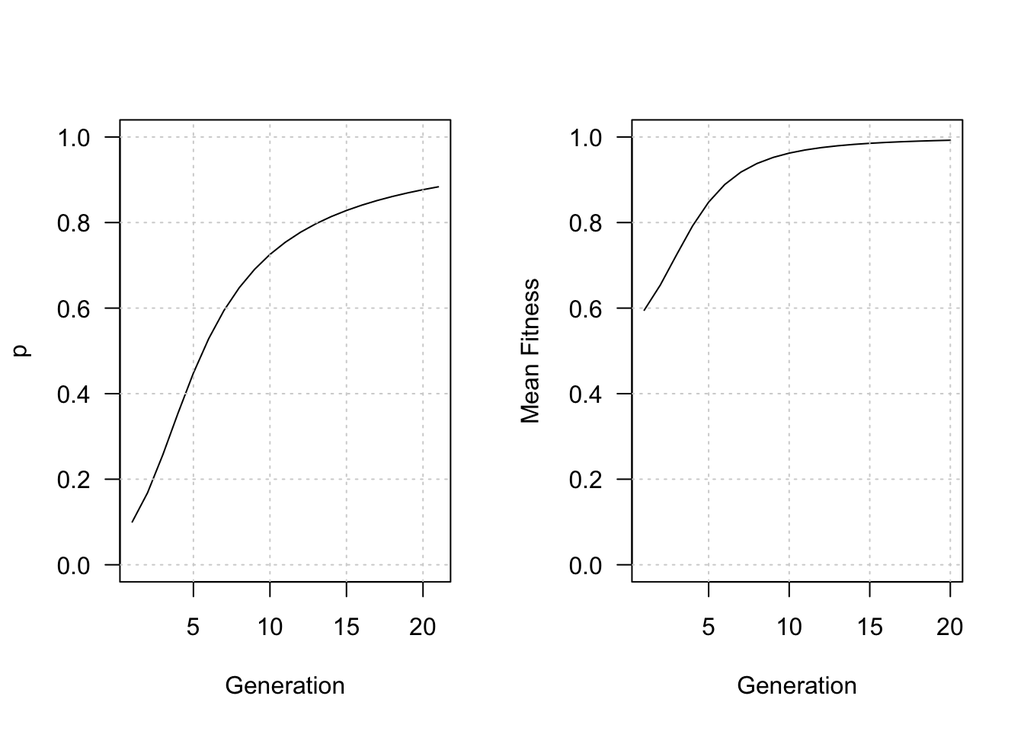

```
## [[1]]
##  [1] 0.1000000 0.1680672 0.2570056 0.3549900 0.4482305 0.5287138 0.5947657
##  [8] 0.6479688 0.6907710 0.7254560 0.7538671 0.7774156 0.7971628 0.8139061
## [15] 0.8282476 0.8406466 0.8514574 0.8609558 0.8693596 0.8768421 0.8835428
##
## [[2]]
##  [1] 0.5950000 0.6539439 0.7239796 0.7919811 0.8477752 0.8889447 0.9178926
##  [8] 0.9380370 0.9521887 0.9623128 0.9697093 0.9752281 0.9794285 0.9826845
## [15] 0.9852506 0.9873033 0.9889675 0.9903334 0.9914665 0.9924161
```

```r
FisherEngine()
```

## R Function For Calculating Heritability From A Selective Breeding Experiment

```r
# FUNCTION For Calculating Heritability From A Selective Breeding Experiment
# 22 November
# NJG

Heritability <- function(x=10,y=20,z=11){
  SelectionDifferential <- y - x
  cat("Selection Differential = ",SelectionDifferential,"\n")
  cat("\n")

  ResponseToSelection <- z - x
  cat("Response To Selection = ",ResponseToSelection, "\n")
  cat("\n")

  h2 <- ResponseToSelection/SelectionDifferential
  cat("Heritability = ",h2, "\n")
  cat("\n")
}
```

```r
Heritability()
```

```
## Selection Differential =  10
##
## Response To Selection =  1
##
## Heritability =  0.1
```

## R Function For Plotting Results Of Common Garden Experiments

```r
# FUNCTION for plotting results of common garden experiments
# 21 November 2015
# NJG

CommonGarden <- function(TraitMeans=c(40,20,70)){
  Pop1 <- rnorm(15,TraitMeans[1],10)
  Pop2 <- rnorm(15,TraitMeans[2],10)
  Pop3 <- rnorm(15,TraitMeans[3],10)
PopData <- c(Pop1,Pop2,Pop3)
Treatment <- rep(c("P1","P2","P3"),each=15)
par(mar=c(6,6,4,2))
BoxPlotDataFrame <- data.frame(x=Treatment,y=PopData)
boxplot(y~x,data=BoxPlotDataFrame,ylab="Trait Value",sub="Donor Source",cex.sub=2,cex.axis=1.5, cex.lab=2,col="bisque")
  }
```

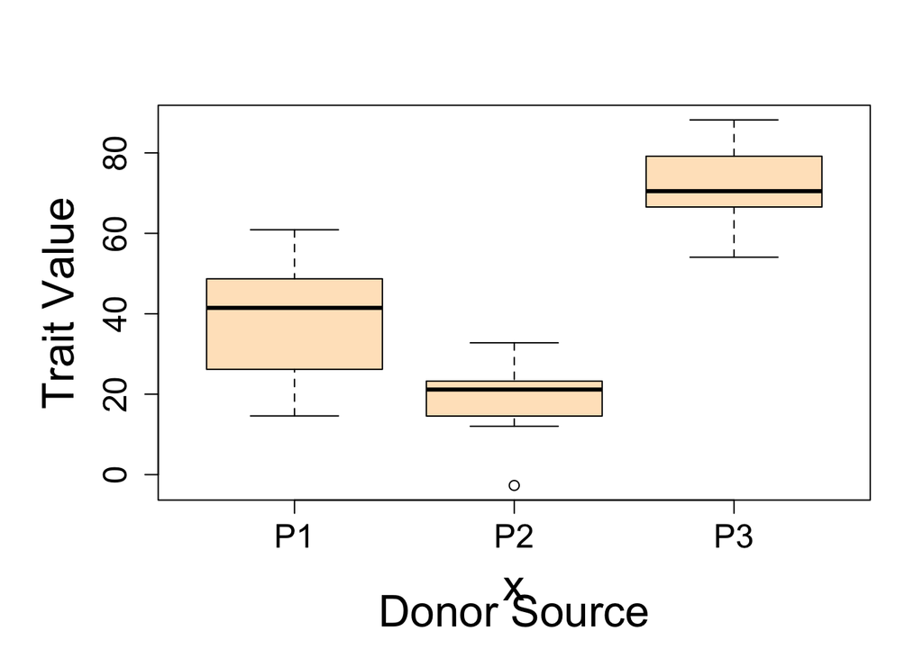

```r
CommonGarden()
```

## R Function For Plotting Results Of Reciprocal Transplant Experiments

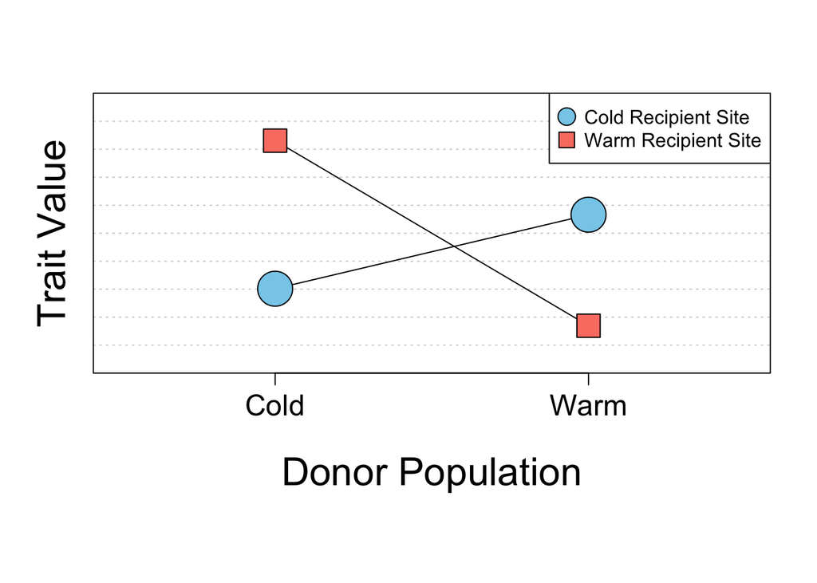

```r
# FUNCTION RecipPlot generates a plot of reciprocal transplant data
# NJG
# 21 November 2015
# The user specifies the mean trait values for each of the 4 treatments
# NJG
# 21 November 2015

RecipPlot <- function(ydata=c(10,20,30,5)){
  # set margins and set up axis locations
  par(mar=c(9,4,4,2))
  xdata <- c(1,1,2,2)

  # set up an empty plot
  plot(x=xdata,y=ydata,xlim=c(0.5,2.5),ylim=c(min(ydata)-5,max(ydata)+5),ann=F,axes=F,type="n")
  grid(nx=0,ny=10)
  # add x axis and labels
  axis(side=1,labels=c("Cold","Warm"),at=c(1,2),tick=T, cex.axis=1.5)
  mtext("Donor Population",side=1,cex=2,line=4)
  mtext("Trait Value",side=2,cex=2, line=1)
  box()

  # add lines and points
  lines(c(1,2),ydata[c(1,2)])
  lines(c(1,2),ydata[c(3,4)])
  points(c(1,2),ydata[c(1,2)],cex=4,pch=21,bg="skyblue")
  points(c(1,2),ydata[c(3,4)],cex=3,pch=22,bg="salmon")

  # add legend
  legend("topright",legend=c("Cold Recipient Site","Warm Recipient Site"),pch=c(21,22),pt.cex=2,pt.bg=c("skyblue","salmon"))

}
RecipPlot()
```